# Introduction to R, part 1k

Steve Simon

Monday, August 10, 2016

This program is part of a series of R programs for the Introduction to R class. This program shows you a sample format for your homework.

1. Read in the data on various body measurements. A description is at –> http://www.amstat.org/publications/jse/datasets/fat.txt and the file can be found at –> http://www.amstat.org/publications/jse/datasets/fat.dat.txt Display the first few rows and the last few rows of the data.
2. List all of the bmi values.
3. List the last row of the data set only.
4. Calculate a summary for bmi.
5. Draw a histogram for bmi and interpret it.
6. Show the association between age and bmi using a correlation.

Here’s how you would do this using R Markdown and an html format.

Answer to 1.

Here are the R commands to read in the file.

```r
fn <- "http://www.amstat.org/publications/jse/datasets/fat.dat.txt"
fd <- read.table(file=fn)
```

Here are the first few rows of the data set.

```r
head(fd)
```

```
##   V1   V2   V3     V4 V5     V6    V7   V8    V9  V10   V11   V12   V13
## 1  1 12.6 12.3 1.0708 23 154.25 67.75 23.7 134.9 36.2  93.1  85.2  94.5
## 2  2  6.9  6.1 1.0853 22 173.25 72.25 23.4 161.3 38.5  93.6  83.0  98.7
## 3  3 24.6 25.3 1.0414 22 154.00 66.25 24.7 116.0 34.0  95.8  87.9  99.2
## 4  4 10.9 10.4 1.0751 26 184.75 72.25 24.9 164.7 37.4 101.8  86.4 101.2
## 5  5 27.8 28.7 1.0340 24 184.25 71.25 25.6 133.1 34.4  97.3 100.0 101.9
## 6  6 20.6 20.9 1.0502 24 210.25 74.75 26.5 167.0 39.0 104.5  94.4 107.8
##    V14  V15  V16  V17  V18  V19
## 1 59.0 37.3 21.9 32.0 27.4 17.1
## 2 58.7 37.3 23.4 30.5 28.9 18.2
## 3 59.6 38.9 24.0 28.8 25.2 16.6
## 4 60.1 37.3 22.8 32.4 29.4 18.2
## 5 63.2 42.2 24.0 32.2 27.7 17.7
## 6 66.0 42.0 25.6 35.7 30.6 18.8
```

Here are the last few rows of the data set.

```r
tail(fd)
```

```
##      V1   V2   V3     V4 V5     V6    V7   V8    V9  V10   V11   V12   V13
## 247 247 29.1 30.2 1.0308 69 215.50 70.50 30.5 152.7 40.8 113.7 107.6 110.0
## 248 248 11.5 11.0 1.0736 70 134.25 67.00 21.1 118.9 34.9  89.2  83.6  88.8
## 249 249 32.3 33.6 1.0236 72 201.00 69.75 29.1 136.1 40.9 108.5 105.0 104.5
## 250 250 28.3 29.3 1.0328 72 186.75 66.00 30.2 133.9 38.9 111.1 111.5 101.7
## 251 251 25.3 26.0 1.0399 72 190.75 70.50 27.0 142.6 38.9 108.3 101.3  97.8
## 252 252 30.7 31.9 1.0271 74 207.50 70.00 29.8 143.7 40.8 112.4 108.5 107.1
##      V14  V15  V16  V17  V18  V19
## 247 63.3 44.0 22.6 37.5 32.6 18.8
## 248 49.6 34.8 21.5 25.6 25.7 18.5
## 249 59.6 40.8 23.2 35.2 28.6 20.1
## 250 60.3 37.3 21.5 31.3 27.2 18.0
## 251 56.0 41.6 22.7 30.5 29.4 19.8
## 252 59.3 42.2 24.6 33.7 30.0 20.9
```

Answer to 2.

Here are all the bmi values.

```r
names(fd) <- c("case","fat.b","fat.s","dens","age","wt","ht","bmi","ffw","neck","chest","abdomen","hip","thigh","knee","ankle","biceps","forearm","wrist")
fd$bmi
```

```
##   [1] 23.7 23.4 24.7 24.9 25.6 26.5 26.2 23.6 24.6 25.8 23.6 26.3 26.3 28.5
##  [15] 27.4 26.3 27.3 29.2 28.2 27.6 27.3 29.1 21.2 21.4 23.2 21.9 20.3 22.9
##  [29] 22.4 23.8 23.6 22.2 23.3 30.5 32.2 32.0 29.1 29.7 48.9 31.8 39.1 29.9
##  [43] 31.2 29.2 19.1 21.3 20.6 20.6 20.4 20.2 21.3 20.6 21.1 19.9 21.1 26.9
##  [57] 27.6 29.3 28.4 29.2 28.2 26.8 27.6 27.9 29.5 28.3 21.3 21.3 22.8 21.6
##  [71] 23.1 21.9 20.8 21.5 23.3 22.9 23.7 26.7 23.0 25.1 25.1 23.4 25.3 24.5
##  [85] 24.7 26.0 24.6 26.0 23.7 23.3 25.4 26.2 23.4 26.3 23.4 26.1 24.8 25.9
##  [99] 23.7 26.7 25.9 23.6 24.0 25.5 26.0 24.8 26.0 26.0 24.0 24.7 25.6 26.3
## [113] 25.6 23.3 24.0 23.4 23.6 24.3 24.6 25.3 26.2 25.5 23.9 23.9 25.6 26.2
## [127] 26.4 23.4 25.2 23.9 23.7 24.3 25.8 24.8 24.5 26.8 23.5 24.1 23.3 26.6
## [141] 24.6 25.3 25.6 21.6 22.1 21.9 27.7 29.8 19.3 31.8 22.5 30.7 19.7 24.4
## [155] 26.1 21.6 30.4 24.6 20.3 24.4 20.4 25.9 24.4 19.8 29.7 28.1 25.3 30.3
## [169] 33.3 25.2 23.4 20.6 24.8 24.3 31.0 21.3 23.7 33.2 27.5 29.8 28.0 18.1
## [183] 22.7 23.0 21.8 23.1 29.7 28.6 27.0 28.0 22.5 29.8 27.4 28.3 21.6 27.2
## [197] 23.1 23.1 22.3 26.4 25.4 22.0 27.6 23.7 32.3 27.6 27.2 26.1 22.9 22.5
## [211] 21.4 27.4 23.0 27.4 22.8 37.6 21.6 22.2 27.2 22.7 24.5 31.0 25.0 22.2
## [225] 26.8 20.0 25.6 25.3 25.4 25.2 24.1 24.9 24.2 25.2 24.1 26.1 25.8 31.9
## [239] 22.6 30.9 20.8 33.9 31.8 30.3 29.9 22.8 30.5 21.1 29.1 30.2 27.0 29.8
```

Answer to 3.

Here is the last row of the data.

```r
fd[252, ]
```

```
##     case fat.b fat.s   dens age    wt ht  bmi   ffw neck chest abdomen
## 252  252  30.7  31.9 1.0271  74 207.5 70 29.8 143.7 40.8 112.4   108.5
##       hip thigh knee ankle biceps forearm wrist
## 252 107.1  59.3 42.2  24.6   33.7      30  20.9
```

Answer to 4.

Here is a summary for bmi.

```r
summary(fd$bmi)
```

```
##    Min. 1st Qu.  Median    Mean 3rd Qu.    Max.
##   18.10   23.10   25.05   25.44   27.33   48.90
```

[[NOTE: INTERPRETATION IS IMPORTANT, BOTH HERE AND FOR THE NEXT TWO QUESTIONS. You don’t have to describe every single number, just pick two or three to talk about.]] Rounding to two significant figures, the mean is 25, the range is 18 to 49.

Answer to 5.

Here is a histogram for bmi.

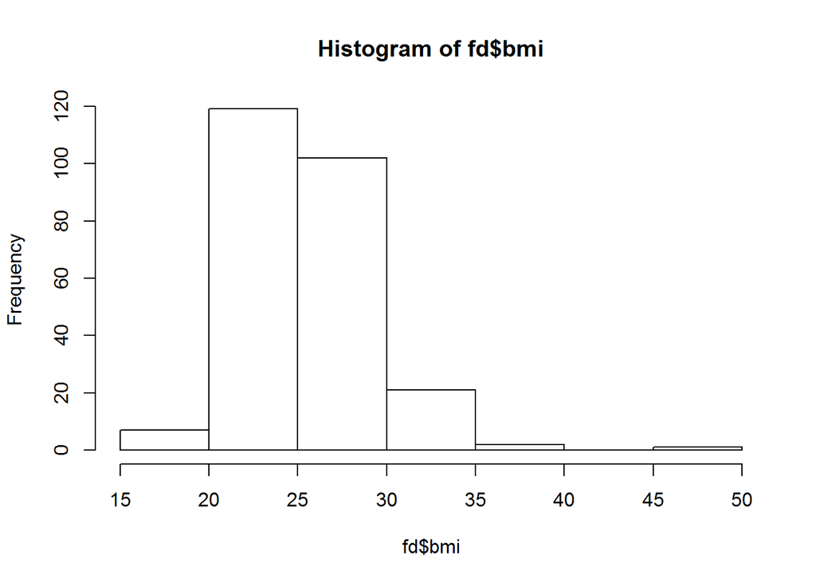

```r
hist(fd$bmi)
```

The distribution is slightly skewed with a possible outlier between 45 and 50.

Answer to 6.

Here is a correlation between bmi and age.

```r
cor(fd$bmi, fd$age)
```

```
## [1] 0.1188513
```

The correlation is 0.12. There is little or no association between bmi and age.